# Learning Machines

## Stats 141B

## Lecture 7

## Prof. Sharpnack

## Lecture slides at http://anson.ucdavis.edu/~jsharpna/141Blectures/

## Lecture repository at https://github.com/jsharpna/141Blectures/

## Inference vs. Prediction

- statistical inference: is this effect significant? is the model correct? etc.
- prediction: does this algorithm predict the response variable well?

### terms

- *supervised learning*: predicting one variable from many others
- *predictor* variables: X variables
- *response* variable: Y variable
- `X`: $n \times p$ design matrix / features
- `Y`: $n$ label vector

```python
!ls -l ../data/winequality-red.csv
```

```
-rw-r--r-- 1 jsharpna jsharpna 84199 Oct  8 10:28 ../data/winequality-red.csv
```

```python
!head ../data/winequality-red.csv
```

```
"fixed acidity";"volatile acidity";"citric acid";"residual sugar";"chlorides";"free sulfur dioxide";"total sulfur dioxide";"density";"pH";"sulphates";"alcohol";"quality"
7.4;0.7;0;1.9;0.076;11;34;0.9978;3.51;0.56;9.4;5
7.8;0.88;0;2.6;0.098;25;67;0.9968;3.2;0.68;9.8;5
7.8;0.76;0.04;2.3;0.092;15;54;0.997;3.26;0.65;9.8;5
11.2;0.28;0.56;1.9;0.075;17;60;0.998;3.16;0.58;9.8;6
7.4;0.7;0;1.9;0.076;11;34;0.9978;3.51;0.56;9.4;5
7.4;0.66;0;1.8;0.075;13;40;0.9978;3.51;0.56;9.4;5
7.9;0.6;0.06;1.6;0.069;15;59;0.9964;3.3;0.46;9.4;5
7.3;0.65;0;1.2;0.065;15;21;0.9946;3.39;0.47;10;7
7.8;0.58;0.02;2;0.073;9;18;0.9968;3.36;0.57;9.5;7
```

Wine dataset description

- 84199 bytes (not large, feel free to load into memory)
- header with quotations " in the text
- each line has floats without quotations
- each datum separated by ;

```python
with open('../data/winequality-red.csv','r') as winefile:
    header = winefile.readline()
    wine_list = [line.strip().split(';') for line in winefile]
```

```python
wine_ar = np.array(wine_list,dtype=np.float64)
```

```python
#Subselect the predictor X and response y
y = wine_ar[:,-1]
X = wine_ar[:,:-1]
n,p = X.shape
```

```python
y.shape, X.shape #just checking
```

```
((1599,), (1599, 11))
```

```python
import statsmodels.api as sm

X = np.hstack((np.ones((n,1)),X)) #add intercept
wine_ols = sm.OLS(y,X) #Initialize the OLS
wine_res = wine_ols.fit()
```

```python
wine_res.summary()
```

OLS Regression Results

| Dep. Variable: | y | R-squared: | 0.361 |
| --- | --- | --- | --- |
| Model: | OLS | Adj. R-squared: | 0.356 |
| Method: | Least Squares | F-statistic: | 81.35 |
| Date: | Mon, 08 Oct 2018 | Prob (F-statistic): | 1.79e-145 |
| Time: | 11:19:22 | Log-Likelihood: | -1569.1 |
| No. Observations: | 1599 | AIC: | 3162. |
| Df Residuals: | 1587 | BIC: | 3227. |
| Df Model: | 11 |  |  |
| Covariance Type: | nonrobust |  |  |

|  | coef | std err | t | P>\|t\| | [0.025 | 0.975] |
| --- | --- | --- | --- | --- | --- | --- |
| const | 10.9826 | 10.597 | 1.036 | 0.300 | -9.804 | 31.769 |
| x1 | 10.9826 | 10.597 | 1.036 | 0.300 | -9.804 | 31.769 |
| x2 | 0.0250 | 0.026 | 0.963 | 0.336 | -0.026 | 0.076 |
| x3 | -1.0836 | 0.121 | -8.948 | 0.000 | -1.321 | -0.846 |
| x4 | -0.1826 | 0.147 | -1.240 | 0.215 | -0.471 | 0.106 |
| x5 | 0.0163 | 0.015 | 1.089 | 0.276 | -0.013 | 0.046 |
| x6 | -1.8742 | 0.419 | -4.470 | 0.000 | -2.697 | -1.052 |
| x7 | 0.0044 | 0.002 | 2.009 | 0.045 | 0.000 | 0.009 |
| x8 | -0.0033 | 0.001 | -4.480 | 0.000 | -0.005 | -0.002 |
| x9 | -17.8812 | 21.633 | -0.827 | 0.409 | -60.314 | 24.551 |
| x10 | -0.4137 | 0.192 | -2.159 | 0.031 | -0.789 | -0.038 |
| x11 | 0.9163 | 0.114 | 8.014 | 0.000 | 0.692 | 1.141 |
| x12 | 0.2762 | 0.026 | 10.429 | 0.000 | 0.224 | 0.328 |

| Omnibus: | 27.376 | Durbin-Watson: | 1.757 |
| --- | --- | --- | --- |
| Prob(Omnibus): | 0.000 | Jarque-Bera (JB): | 40.965 |
| Skew: | -0.168 | Prob(JB): | 1.27e-09 |
| Kurtosis: | 3.708 | Cond. No. | 2.30e+17 |

Warnings:  
[1] Standard Errors assume that the covariance matrix of the errors is correctly specified.  
[2] The smallest eigenvalue is 1.11e-28. This might indicate that there are  
strong multicollinearity problems or that the design matrix is singular.

### Linear model

$$\hat y_i = \beta_0 + \sum_{j=1}^p \beta_j x_{i,j}$$

### Inference in linear models

- statistically test for significance of effects
- requires normality assumptions, homoscedasticity, linear model is correct
- hard to obtain significance for individual effect under colinearity

### Prediction perspective

- think of OLS as a black-box model for predicting $Y | X$
- how do we evaluate performance of prediction?
- how do we choose between multiple OLS models?

### Machine Learning

“How can we build computer systems that automatically improve with experience, and what are the fundamental laws that govern all learning processes?” - Tom Mitchell

- *Task:* What do you want the system to do?
- *Performance Metric:* How do we evaluate how well it is doing the task?
- *Experience:* How does the system collect data and interact with its environment?

### Supervised learning

Learning machine that takes $p$-dimensional data $x = (x_1, \ldots, x_p)$ and predicts $y \in \mathcal Y$.

- *Task:* **Predict** $y$ given $x$ as $\hat y$
- *Performance Metric:* **Loss** measured with some function $\ell(\hat y,y)$
- *Experience:* **Fit** the model with training data $\{x_i,y_i\}_{i=1}^{n_0}$

### Linear Regression

- **Fit**: Compute $\hat \beta$ from OLS with training data $\{x_i,y_i\}_{i=1}^{n_0}$
- **Predict**: For a new predictor $x_{n+1}$ predict $$\hat y = \hat \beta_0 + \sum_{j=1}^p \hat \beta_j x_j$$
- **Loss**: Observe new response $y_{n+1}$ and see loss $$\ell(\hat y,y_{n+1}) = (\hat y - y_{n+1})^2$$

### Life satisfaction data

```
Text(0.5,1,'Life Satisfaction Index')
```

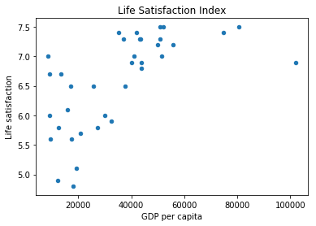

```python
_ = full_country_stats.plot("GDP per capita",'Life satisfaction',kind='scatter')
plt.title('Life Satisfaction Index')
```

```python
full_country_stats.head()
```

| Country | Air pollution | Assault rate | Consultation on rule-making | Dwellings without basic facilities | Educational attainment | Employees working very long hours | Employment rate | Homicide rate | Household net adjusted disposable income | Household net financial wealth | ... | Time devoted to leisure and personal care | Voter turnout | Water quality | Years in education | Subject Descriptor | Units | Scale | Country/Series-specific Notes | GDP per capita | Estimates Start After |
| --- | --- | --- | --- | --- | --- | --- | --- | --- | --- | --- | --- | --- | --- | --- | --- | --- | --- | --- | --- | --- | --- |
| Brazil | 18.0 | 7.9 | 4.0 | 6.7 | 45.0 | 10.41 | 67.0 | 25.5 | 11664.0 | 6844.0 | ... | 14.97 | 79.0 | 72.0 | 16.3 | Gross domestic product per capita, current prices | U.S. dollars | Units | See notes for: Gross domestic product, curren... | 8669.998 | 2014.0 |
| Mexico | 30.0 | 12.8 | 9.0 | 4.2 | 37.0 | 28.83 | 61.0 | 23.4 | 13085.0 | 9056.0 | ... | 13.89 | 63.0 | 67.0 | 14.4 | Gross domestic product per capita, current prices | U.S. dollars | Units | See notes for: Gross domestic product, curren... | 9009.280 | 2015.0 |
| Russia | 15.0 | 3.8 | 2.5 | 15.1 | 94.0 | 0.16 | 69.0 | 12.8 | 19292.0 | 3412.0 | ... | 14.97 | 65.0 | 56.0 | 16.0 | Gross domestic product per capita, current prices | U.S. dollars | Units | See notes for: Gross domestic product, curren... | 9054.914 | 2015.0 |
| Turkey | 35.0 | 5.0 | 5.5 | 12.7 | 34.0 | 40.86 | 50.0 | 1.2 | 14095.0 | 3251.0 | ... | 13.42 | 88.0 | 62.0 | 16.4 | Gross domestic product per capita, current prices | U.S. dollars | Units | See notes for: Gross domestic product, curren... | 9437.372 | 2013.0 |
| Hungary | 15.0 | 3.6 | 7.9 | 4.8 | 82.0 | 3.19 | 58.0 | 1.3 | 15442.0 | 13277.0 | ... | 15.04 | 62.0 | 77.0 | 17.6 | Gross domestic product per capita, current prices | U.S. dollars | Units | See notes for: Gross domestic product, curren... | 12239.894 | 2015.0 |

5 rows × 30 columns

```python
def loss(yhat,y):
    """sqr error loss"""
    return (yhat - y)**2

def fit(X,Y):
    """fit the OLS from training w/o intercept"""
    lin1 = LinearRegression(fit_intercept=True) # OLS from sklearn
    lin1.fit(X,Y) # fit OLS
    return np.append(lin1.intercept_,lin1.coef_) # return betahat

def predict(x, betahat):
    """predict for point x"""
    return betahat[0] + x @ betahat[1:]
```

### Training-test split

Simulate the fit/predict/loss:

- randomly split data into training and test set
- fit on training set
- predict on each X datum on test set
- observe losses of predicted Y and test Y's

```python
## randomly shuffle data and split
Ind = np.arange(n)
np.random.shuffle(Ind)
train_size = 2 * n // 3 +1 # set training set size
X_tr, X_te = X[Ind[:train_size],:], X[Ind[train_size:],:]
Y_tr, Y_te = Y[Ind[:train_size]], Y[Ind[train_size:]]
```

```python
## compute losses on test set
betahat = fit(X_tr,Y_tr)
Y_hat_te = [predict(x,betahat) for x in X_te]
test_losses = [loss(yhat,y) for yhat,y in zip(Y_hat_te,Y_te)]

## compute losses on train set
Y_hat_tr = [predict(x,betahat) for x in X_tr]
train_losses = [loss(yhat,y) for yhat,y in zip(Y_hat_tr,Y_tr)]
```

```python
train_losses
```

```
[1.2563745875348131e-24,
 4.652890945610781e-25,
 2.6537280851634837e-27,
 3.852875547189944e-26,
 5.739822943869552e-25,
 3.478876592024662e-28,
 1.944463245279272e-26,
 4.146450133067943e-25,
 5.836308521187134e-26,
 8.486881162729733e-26,
 1.5683343656698936e-24,
 5.3043007267060834e-27,
 6.446697535210944e-25,
 4.090030012265631e-24,
 1.4590771302967834e-24,
 3.17087374019017e-25,
 7.679087595783417e-26,
 8.532319550870464e-27,
 3.0323813196695694e-27,
 7.052495378766368e-26,
 3.538770067392662e-24,
 5.4316039441470294e-24,
 4.0541841727323885e-24,
 3.2508169043252675e-26,
 1.4892715703050229e-24]
```

```python
test_losses
```

```
[0.3225148889036824,
 1.2231472961532266,
 14.003074711166326,
 3.649069754309634,
 0.20284334151812158,
 0.2104567170965582,
 17.05979108438917,
 5.416619933357851,
 15.569468762765261,
 4.829757416307495,
 0.3908933373326495]
```

```python
print("train avg loss: {}\ntest avg loss: {}".format(np.mean(train_losses), np.mean(test_losses)))
```

```
train avg loss: 1.0281687712413355e-24
test avg loss: 5.716148840299997
```

```python
X_tr.shape
```

```
(25, 24)
```

```python
def train_test_split(X,Y,split_pr = 0.5):
    """train-test split"""
    n,p = X.shape
    Ind = np.arange(n)
    np.random.shuffle(Ind)
    train_size = int(split_pr * n) # set training set size
    X_tr, X_te = X[Ind[:train_size],:], X[Ind[train_size:],:]
    Y_tr, Y_te = Y[Ind[:train_size]], Y[Ind[train_size:]]
    return (X_tr,Y_tr), (X_te, Y_te)
```

```python
Y = wine_ar[:,-1]
X = wine_ar[:,:-1]
(X_tr,Y_tr), (X_te, Y_te) = train_test_split(X,Y)
```

```python
## compute losses on test set
betahat = fit(X_tr,Y_tr)
Y_hat_te = [predict(x,betahat) for x in X_te]
test_losses = [loss(yhat,y) for yhat,y in zip(Y_hat_te,Y_te)]

## compute losses on train set
Y_hat_tr = [predict(x,betahat) for x in X_tr]
train_losses = [loss(yhat,y) for yhat,y in zip(Y_hat_tr,Y_tr)]
```

```python
print("train avg loss: {}\ntest avg loss: {}".format(np.mean(train_losses), np.mean(test_losses)))
```

```
train avg loss: 0.4133294181694419
test avg loss: 0.43249088406204733
```

```python
X.shape
```

```
(1599, 11)
```